# Detailed Insights: Australia

## Welcome!

You have reached the CCN Inventory Tool Detailed Insights Report.

Congratulations! This geography has available data.

Potential data availability within the Inventory Tool ranges from Tier I, Tier II, or Tier III Carbon stock estimates.

This document includes country-specific insights and more detailed analysis, including carbon stocks, emissions factors, and ecosystem wetland area for mangrove, marsh, and seagrass habitats. This report details information for the selected geography, **Australia**.

Explore the rest of the dashboard for more exciting visualizations, map features and data.

Resources referenced to calculate estimates for **Australia** are listed below under ‘References’ at the end of this document.

If you have any questions or data you would like to add to the Coastal Carbon Network, please reach out to us at CoastalCarbon@si.edu.

## Total Carbon Stock Estimates

Total Carbon stock estimates were calculated for each geography in total, and for mangrove, tidal marsh, and seagrass habitats when available.

We estimate that **Australia** contains a mean estimate of 2.07008^{8} metric tonnes soil Carbon.

We estimate that **Australia** contains between 2.53165^{8} to 1.60852^{8} metric tonnes of soil C to a depth of 1 m, with a mean estimate of 2.07008^{8} metric tonnes C.

Total Geography Level Carbon Stocks

[output not shown]

This total estimate includes total mangrove soil carbon stocks, with a mean estimate of 1.72848^{8} metric tonnes of soil C to a depth of 1 meter.

## Wetland Areas and Activities

We estimate mangrove area in **Australia** to be 8.408^{5} to 1.11^{6} hectares, with a mean estimate of 9.575^{5} hectares according to Global Mangrove Watch Bunting et al. (2018).

We estimate seagrass area to be **Australia** to be a mean of 8.301^{6} hectares, according to Len J. McKenzie et al. (2020), which aggregates global seagrass data from a number of sources.

## Calculated Stocks and Emissions Factors

This section of the report details whether data is available to estimate Tier I, Tier II, or Tier III value estimates for tidal marsh, mangrove, and seagrass ecosystems in **Australia**.

If data for the selected country is available in the Coastal Carbon Atlas, we have applied a Tier II emission factor based on a simple average of country specific data queried from the Atlas.

Data from **Australia** included in the Coastal Carbon Atlas consists of 181 soil profiles from 135 watersheds. This data comes from 4 distinct habitat type(s).

In the case that there is not yet any country specific information in the Coastal Carbon Atlas, we instead applied IPCC Tier I estimate. IPCC Tier I estimates for mangrove, marsh, and seagrass ecosystems are listed below.

The table in this section also details whether the calculated Tier II value is significantly different from the estimated Tier I values. This is observed in the “Overlap” column.

IPCC Tier I Value Estimates

| Habitat | Mean | Lower_CI | Upper_CI |
| --- | --- | --- | --- |
| mangrove | 386 | 351 | 424 |
| marsh | 255 | 254 | 297 |
| seagrass | 108 | 84 | 139 |

## Data Availiability by Tier

Availiability of Tier I and Tier II Data

| Country | Territory | Habitat | Tier | Overlap |
| --- | --- | --- | --- | --- |
| Australia | Australia | mangrove | Tier II | Country-specific average is significantly less than Tier I |
| Australia | Australia | marsh | Tier II | Country-specific average is significantly less than Tier I |
| Australia | Australia | seagrass | Tier II | Country-specific average is significantly greater than Tier I |

### Tier I Carbon Stocks

This section includes Tier I Carbon Stocks included for **Australia**. In the case that all habitats; mangrove, tidal marsh, and seagrass have availiable Tier II estimates, please refer to Table 2: IPCC Tier I Value Estimates for applicable Tier I values.

### Tier II Carbon Stocks

This table includes Tier II Carbon Stock estimates for **Australia**. Estimates in this table were derived from data queried from the Coastal Carbon Atlas.

A selected country may have available Tier II values for one or multiple habitats, this is dependent on core data accessible through the Coastal Carbon Atlas. At the time of analysis, referencing Version 1.5.0, **Australia** represents a total of 181 cores across 4 distinct habitats.

Tier II Carbon Stock Estimates

| Country | Territory | Habitat | Mean Stock (MgHa) | Lower CI | Upper CI | Standard Error |
| --- | --- | --- | --- | --- | --- | --- |
| Australia | Australia | mangrove | 181 | 153 | 208 | 13.96050 |
| Australia | Australia | marsh | 150 | 119 | 181 | 15.71915 |
| Australia | Australia | seagrass | 456 | 203 | 709 | 128.99371 |

### Tier III Carbon Stocks

If there are no Tier III estimates associated with the selected country and specific habitat of interest, please refer to above Tier I and Tier II tables.

Tier III Carbon Stock Estimates

| Country | Territory | Habitat | Mean Stock (MgHa) | Lower CI | Upper CI |
| --- | --- | --- | --- | --- | --- |
| Australia | Australia | mangrove | 312 | 285 | 339 |
| Australia | Australia | marsh | 256 | 231 | 281 |

## Visualizations

### 1. Data Metrics

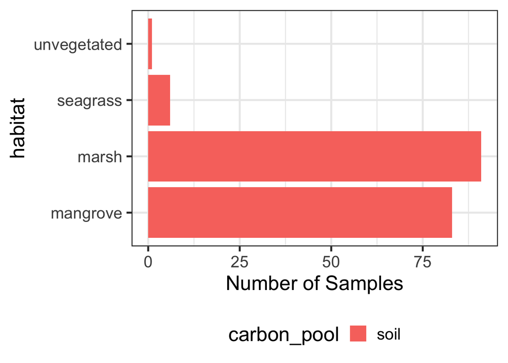

### 2. Emissions Factors

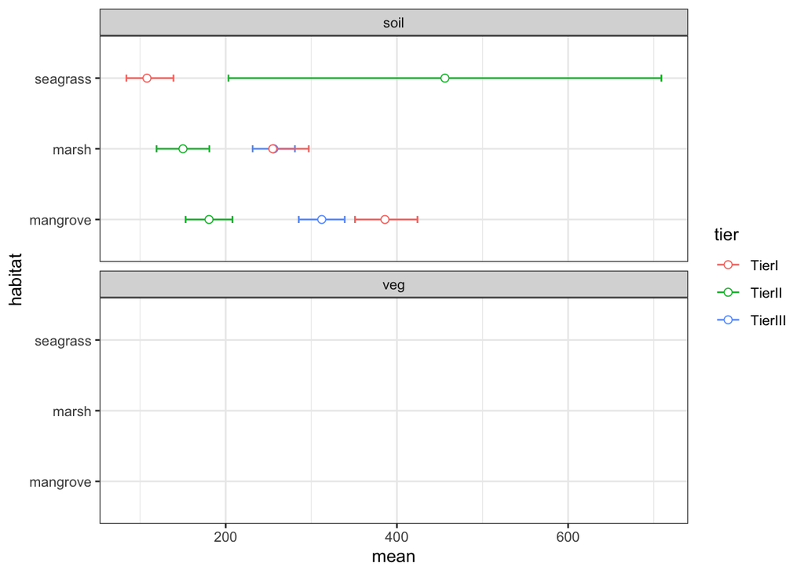

### 3. Activity Data

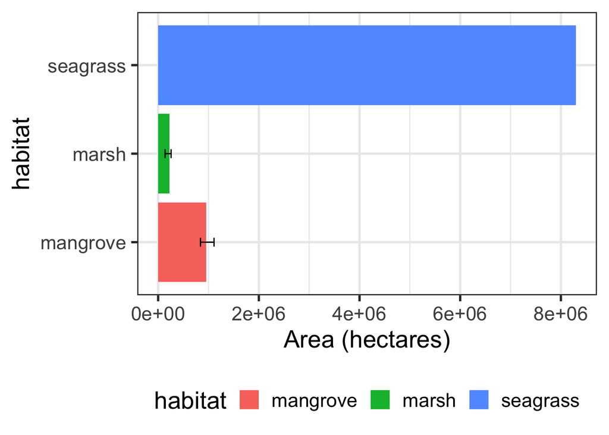

## References

AB, Carter, and Taylor HA & Rasheed MA. 2014. “Torres Strait Mapping: Seagrass Consolidation 2002-2014.” JCU Publication, Report no. 14/55, Centre for Tropical Water & Aquatic Ecosystem Research, Cairns, 47 pp.

Adame, M. F., R. Reef, V. N. L. Wong, S. R. Balcombe, M. P. Turschwell, E. Kavehei, D. C. Rodr’ıguez, J. J. Kelleway, P. Masque, and M. Ronan. 2019. “Carbon and Nitrogen Sequestration of Melaleuca Floodplain Wetlands in Tropical Australia.” *Ecosystems* 23 (2): 454–66. https://doi.org/10.1007/s10021-019-00414-5.

A.Lafratta, O.Serrano, P.Masqu’e, M.A.Mateo, M.Fernandes, S.Gaylard, and P.S.Lavery. 2020. “Challenges to Select Suitable Habitats and Demonstrate ‘Additionality’ in Blue Carbon Projects: A Seagrass Case Study.” *Ocean & Coastal Management*. https://doi.org/https://doi.org/10.1016/j.ocecoaman.2020.105295.

Allen, Diane E., Ram C. Dalal, Heinz Rennenberg, Rikke Louise Meyer, Steven Reeves, and Susanne Schmidt. 2007. “Spatial and Temporal Variation of Nitrous Oxide and Methane Flux Between Subtropical Mangrove Sediments and the Atmosphere.” *Soil Biology and Biochemistry* 39 (2): 622–31. https://doi.org/10.1016/j.soilbio.2006.09.013.

Alongi, D. M., F. Tirendi, P. Dixon, L. A. Trott, and G. J. Brunskill. 1999. “Mineralization of Organic Matter in Intertidal Sediments of a Tropical Semi-Enclosed Delta.” *Estuarine, Coastal and Shelf Science* 48 (4): 451–67. https://doi.org/10.1006/ecss.1998.0465.

Alongi, D. M, F Tirendi, and B. F Clough. 2000. “Below-Ground Decomposition of Organic Matter in Forests of the Mangroves Rhizophora Stylosa and Avicennia Marina Along the Arid Coast of Western Australia.” *Aquatic Botany* 68 (2): 97–122. https://doi.org/10.1016/s0304-3770(00)00110-8.

Alongi, Daniel M. 1996. “The Dynamics of Benthic Nutrient Pools and Fluxes in Tropical Mangrove Forests.” *Journal of Marine Research* 54 (1): 123–48. https://doi.org/10.1357/0022240963213475.

Alongi, DM, F Tirendi, LA Trott, and TT Xuan. 2000. “Benthic Decomposition Rates and Pathways in Plantations of the Mangrove Rhizophora Apiculata in the Mekong Delta, Vietnam.” *Marine Ecology Progress Series* 194: 87–101. https://doi.org/10.3354/meps194087.

Authority, NSW Marine Parks. 2010. “Natural Values of Lord Howe Island Marine Park.” NSW Marine Parks Authority, Hurstville, NSW.

Beasy, Kim M., and Joanna C. Ellison. 2013. “Comparison of Three Methods for the Quantification of Sediment Organic Carbon in Salt Marshes of the Rubicon Estuary, Tasmania, Australia.” *International Journal of Biology* 5 (4). https://doi.org/10.5539/ijb.v5n4p1.

Brunskill, G. J., I. Zagorskis, and J. Pfitzner. 2002. “Carbon Burial Rates in Sediments and a Carbon Mass Balance for the Herbert River Region of the Great Barrier Reef Continental Shelf, North Queensland, Australia.” *Estuarine, Coastal and Shelf Science* 54 (4): 677–700. https://doi.org/10.1006/ecss.2001.0852.

Bunting, Pete, Ake Rosenqvist, Richard M. Lucas, Lisa-Maria Rebelo, Lammert Hilarides, Nathan Thomas, Andy Hardy, Takuya Itoh, Masanobu Shimada, and C. Max Finlayson. 2018. “The Global Mangrove Watch—a New 2010 Global Baseline of Mangrove Extent.” *Remote Sensing* 10 (10): 1669. https://doi.org/10.3390/rs10101669.

Carter, A. B., McKenna, S. A., Rasheed, M. A., McKenzie L, and Coles R. G. 2016. “Seagrass Mapping Synthesis: A Resource for Coastal Management in the Great Barrier Reef World Heritage Area.” National Environmental Science Programme. Reef; Rainforest Research Centre Limited, Cairns (22 pp).

Carter, A. B., Rasheed, and M. A. 2016. “Assessment of Key Dugong and Turtle Seagrass Resources in Northwest Torres Strait.” Report to the National Environmental Science Programme; Torres Strait Regional Authority.Reef; Rainforest Research Centre Limited, Cairns, 41 pp.

Coles, R, L McKenzie, G De’ath, A Roelofs, and W Lee Long. 2009. “Spatial Distribution of Deepwater Seagrass in the Inter-Reef Lagoon of the Great Barrier Reef World Heritage Area.” *Marine Ecology Progress Series* 392 (October): 57–68. https://doi.org/10.3354/meps08197.

Conrad, Stephen, Dylan R. Brown, Paula Gomez Alvarez, Bronte Bates, Nizam Ibrahim, Alex Reid, Luciana Silva Monteiro, et al. 2019. “Does Regional Development Influence Sedimentary Blue Carbon Stocks? A Case Study from Three Australian Estuaries.” *Frontiers in Marine Science* 5 (January). https://doi.org/10.3389/fmars.2018.00518.

Consulting, Natura. 2012. “Seagrass Health and Abundance Study (2012).” Report prepared for the Gold Coast City Council.

Coppe, C., McKenzie, L.J., Brodie, and J. 2015. “Status of Coastal and Marine Assets in the Eastern Cape York Region. TropWATER Report No 15/65.” Centre for Tropical Water & Aquatic Ecosyystem Research, James Cook University, QLD.

Ewers Lewis, Carolyn J., Paul E. Carnell, Jonathan Sanderman, Jeffrey A. Baldock, and Peter I. Macreadie. 2017. “Variability and Vulnerability of Coastal ‘Blue Carbon’ Stocks: A Case Study from Southeast Australia.” *Ecosystems* 21 (2): 263–79. https://doi.org/10.1007/s10021-017-0150-z.

Eyre, BD, and AJP Ferguson. 2002a. “Comparison of Carbon Production and Decomposition, Benthic Nutrient Fluxes and Denitrification in Seagrass, Phytoplankton, Benthic Microalgae- and Macroalgae-Dominated Warm-Temperate Australian Lagoons.” *Marine Ecology Progress Series* 229: 43–59. https://doi.org/10.3354/meps229043.

———. 2002b. “Comparison of Carbon Production and Decomposition, Benthic Nutrient Fluxes and Denitrification in Seagrass, Phytoplankton, Benthic Microalgae- and Macroalgae-Dominated Warm-Temperate Australian Lagoons.” *Marine Ecology Progress Series* 229: 43–59. https://doi.org/10.3354/meps229043.

Fonseca, Gustavo, Pat Hutchings, and Fabiane Gallucci. 2011a. “Meiobenthic Communities of Seagrass Beds (Zostera Capricorni) and Unvegetated Sediments Along the Coast of New South Wales, Australia.” *Estuarine, Coastal and Shelf Science* 91 (1): 69–77. https://doi.org/10.1016/j.ecss.2010.10.003.

———. 2011b. “Meiobenthic Communities of Seagrass Beds (Zostera Capricorni) and Unvegetated Sediments Along the Coast of New South Wales, Australia.” *Estuarine, Coastal and Shelf Science* 91 (1): 69–77. https://doi.org/10.1016/j.ecss.2010.10.003.

Fourqurean, James W., Carlos M. Duarte, Hilary Kennedy, NÃria Mar ‘a, Marianne Holmer, Miguel Angel Mateo, Eugenia T. Apostolaki, et al. 2012a. “Seagrass Ecosystems as a Globally Significant Carbon Stock.” *Nature Geoscience* 5 (7): 505–9. https://doi.org/10.1038/ngeo1477.

———, et al. 2012b. “Seagrass Ecosystems as a Globally Significant Carbon Stock.” *Nature Geoscience* 5 (7): 505–9. https://doi.org/10.1038/ngeo1477.

———, et al. 2012c. “Seagrass Ecosystems as a Globally Significant Carbon Stock.” *Nature Geoscience* 5 (7): 505–9. https://doi.org/10.1038/ngeo1477.

———, et al. 2012d. “Seagrass Ecosystems as a Globally Significant Carbon Stock.” *Nature Geoscience* 5 (7): 505–9. https://doi.org/10.1038/ngeo1477.

———, et al. 2012e. “Seagrass Ecosystems as a Globally Significant Carbon Stock.” *Nature Geoscience* 5 (7): 505–9. https://doi.org/10.1038/ngeo1477.

———, et al. 2012f. “Seagrass Ecosystems as a Globally Significant Carbon Stock.” *Nature Geoscience* 5 (7): 505–9. https://doi.org/10.1038/ngeo1477.

———, et al. 2012g. “Seagrass Ecosystems as a Globally Significant Carbon Stock.” *Nature Geoscience* 5 (7): 505–9. https://doi.org/10.1038/ngeo1477.

———, et al. 2012h. “Seagrass Ecosystems as a Globally Significant Carbon Stock.” *Nature Geoscience* 5 (7): 505–9. https://doi.org/10.1038/ngeo1477.

———, et al. 2012i. “Seagrass Ecosystems as a Globally Significant Carbon Stock.” *Nature Geoscience* 5 (7): 505–9. https://doi.org/10.1038/ngeo1477.

———, et al. 2012j. “Seagrass Ecosystems as a Globally Significant Carbon Stock.” *Nature Geoscience* 5 (7): 505–9. https://doi.org/10.1038/ngeo1477.

———, et al. 2012l. “Seagrass Ecosystems as a Globally Significant Carbon Stock.” *Nature Geoscience* 5 (7): 505–9. https://doi.org/10.1038/ngeo1477.

———, et al. 2012k. “Seagrass Ecosystems as a Globally Significant Carbon Stock.” *Nature Geoscience* 5 (7): 505–9. https://doi.org/10.1038/ngeo1477.

———, et al. 2012m. “Seagrass Ecosystems as a Globally Significant Carbon Stock.” *Nature Geoscience* 5 (7): 505–9. https://doi.org/10.1038/ngeo1477.

———, et al. 2012o. “Seagrass Ecosystems as a Globally Significant Carbon Stock.” *Nature Geoscience* 5 (7): 505–9. https://doi.org/10.1038/ngeo1477.

———, et al. 2012n. “Seagrass Ecosystems as a Globally Significant Carbon Stock.” *Nature Geoscience* 5 (7): 505–9. https://doi.org/10.1038/ngeo1477.

———, et al. 2012p. “Seagrass Ecosystems as a Globally Significant Carbon Stock.” *Nature Geoscience* 5 (7): 505–9. https://doi.org/10.1038/ngeo1477.

———, et al. 2012q. “Seagrass Ecosystems as a Globally Significant Carbon Stock.” *Nature Geoscience* 5 (7): 505–9. https://doi.org/10.1038/ngeo1477.

Gallagher, John Barry, Vishnu Prahalad, and John Aalders. 2021. “Inorganic and Black Carbon Hotspots Constrain Blue Carbon Mitigation Services Across Tropical Seagrass and Temperate Tidal Marshes.” *Wetlands* 41 (5). https://doi.org/10.1007/s13157-021-01460-3.

Gorham, Connor, Paul Lavery, Jeffrey J. Kelleway, Cristian Salinas, and Oscar Serrano. 2020. “Soil Carbon Stocks Vary Across Geomorphic Settings in Australian Temperate Tidal Marsh Ecosystems.” *Ecosystems* 24 (2): 319–34. https://doi.org/10.1007/s10021-020-00520-9.

Holmer, Marianne, and Morten S. Frederiksen. 2007. “Stimulation of Sulfate Reduction Rates in Mediterranean Fish Farm Sediments Inhabited by the Seagrass Posidonia Oceanica.” *Biogeochemistry* 85 (2): 169–84. https://doi.org/10.1007/s10533-007-9127-x.

Howe, A. J., and J. F. Rodrand P. M. Saco. 2009. “Surface Evolution and Carbon Sequestration in Disturbed and Undisturbed Wetland Soils of the Hunter Estuary, Southeast Australia.” *Estuarine, Coastal and Shelf Science* 84 (1): 75–83. https://doi.org/10.1016/j.ecss.2009.06.006.

Hyland, S. J, Butler, C. T, Courtney, A. J, and Queensland. Department of Primary Industries. 1989. *Distribution of Seagrass in the Moreton Region from Coolangatta to Noosa*. Dept. of Primary Industries, Queensland Government Brisbane 1989. https://nla.gov.au/nla.cat-vn4282217.

Kelly, C., Chaffer, and K. 2012. “Ecological Investigations to Support the Broadwater Masterplan. Report to Project Gold Coast City Council Report No GC1(2003)0.” VDM Consulting (QLD) Pty Ltd, Southport, Queensland.

Lafratta, Anna, Oscar Serano, Pere Masque, Miguel-Angel Mateo, Milena Fernandes, Sam Gaylard, and Paul Lavery. 2018. “Importance of Habitat Selection for Blue Carbon Projects: Doubtful Additionality in a Seagrass Case Study.” https://doi.org/10.25958/5b57cce84b1ce.

Livesley, Stephen J., and Sascha M. Andrusiak. 2012. “Temperate Mangrove and Salt Marsh Sediments Are a Small Methane and Nitrous Oxide Source but Important Carbon Store.” *Estuarine, Coastal and Shelf Science* 97 (January): 19–27. https://doi.org/10.1016/j.ecss.2011.11.002.

Lucieer, Vanessa, Craig Johnson, Peter Walsh, Emma Flukes, Claire Butler, and Roger Proctor. 2017. “Seamap Australia - National Seafloor Habitat V1.0.” Institute for Marine; Antarctic Studies (IMAS), University of Tasmania (UTAS). https://doi.org/10.25959/5C06FC1BEDED6.

Maher, D. T., and B. D. Eyre. 2010a. “Benthic Fluxes of Dissolved Organic Carbon in Three Temperate Australian Estuaries: Implications for Global Estimates of Benthic DOC Fluxes.” *Journal of Geophysical Research* 115 (December). https://doi.org/10.1029/2010jg001433.

———. 2010b. “Benthic Fluxes of Dissolved Organic Carbon in Three Temperate Australian Estuaries: Implications for Global Estimates of Benthic DOC Fluxes.” *Journal of Geophysical Research* 115 (December). https://doi.org/10.1029/2010jg001433.

Matsui, and Naohiro. 1998. “Estimated Stocks of Organic Carbon in Mangrove Roots and Sediments in Hinchinbrook Channel, Australia.” *Mangroves and Salt Marshes* 4 (2). https://doi.org/10.1023/A:1009959909208.

Maxwell, Tania L., Andr’e S. Rovai, Maria Fernanda Adame, Janine B. Adams, Jos’e ’Alvarez-Rogel, William E. N. Austin, Kim Beasy, et al. 2023a. “Global Dataset of Soil Organic Carbon in Tidal Marshes.” *Scientific Data* 10 (1). https://doi.org/10.1038/s41597-023-02633-x.

———, et al. 2023b. “Global Dataset of Soil Organic Carbon in Tidal Marshes.” *Scientific Data* 10 (1). https://doi.org/10.1038/s41597-023-02633-x.

———, et al. 2023c. “Global Dataset of Soil Organic Carbon in Tidal Marshes.” *Scientific Data* 10 (1). https://doi.org/10.1038/s41597-023-02633-x.

———, et al. 2023d. “Global Dataset of Soil Organic Carbon in Tidal Marshes.” *Scientific Data* 10 (1). https://doi.org/10.1038/s41597-023-02633-x.

———, et al. 2023e. “Global Dataset of Soil Organic Carbon in Tidal Marshes.” *Scientific Data* 10 (1). https://doi.org/10.1038/s41597-023-02633-x.

———, et al. 2023f. “Global Dataset of Soil Organic Carbon in Tidal Marshes.” *Scientific Data* 10 (1). https://doi.org/10.1038/s41597-023-02633-x.

———, et al. 2023g. “Global Dataset of Soil Organic Carbon in Tidal Marshes.” *Scientific Data* 10 (1). https://doi.org/10.1038/s41597-023-02633-x.

———, et al. 2023h. “Global Dataset of Soil Organic Carbon in Tidal Marshes.” *Scientific Data* 10 (1). https://doi.org/10.1038/s41597-023-02633-x.

———, et al. 2023i. “Global Dataset of Soil Organic Carbon in Tidal Marshes.” *Scientific Data* 10 (1). https://doi.org/10.1038/s41597-023-02633-x.

Maxwell, Tania L., Andr’e S Rovai, Maria Fernanda Adame, Janine B. Adams, Jos’e ’Alvarez-Rogel, William E. N. Austin, Kim Beasy, et al. 2023j. “Database: Tidal Marsh Soil Organic Carbon (MarSOC) Dataset.” Zenodo. https://doi.org/10.5281/ZENODO.8414110.

———, et al. 2023k. “Database: Tidal Marsh Soil Organic Carbon (MarSOC) Dataset.” Zenodo. https://doi.org/10.5281/ZENODO.8414110.

———, et al. 2023l. “Database: Tidal Marsh Soil Organic Carbon (MarSOC) Dataset.” Zenodo. https://doi.org/10.5281/ZENODO.8414110.

———, et al. 2023m. “Database: Tidal Marsh Soil Organic Carbon (MarSOC) Dataset.” Zenodo. https://doi.org/10.5281/ZENODO.8414110.

———, et al. 2023n. “Database: Tidal Marsh Soil Organic Carbon (MarSOC) Dataset.” Zenodo. https://doi.org/10.5281/ZENODO.8414110.

———, et al. 2023o. “Database: Tidal Marsh Soil Organic Carbon (MarSOC) Dataset.” Zenodo. https://doi.org/10.5281/ZENODO.8414110.

———, et al. 2023p. “Database: Tidal Marsh Soil Organic Carbon (MarSOC) Dataset.” Zenodo. https://doi.org/10.5281/ZENODO.8414110.

———, et al. 2023q. “Database: Tidal Marsh Soil Organic Carbon (MarSOC) Dataset.” Zenodo. https://doi.org/10.5281/ZENODO.8414110.

———, et al. 2023r. “Database: Tidal Marsh Soil Organic Carbon (MarSOC) Dataset.” Zenodo. https://doi.org/10.5281/ZENODO.8414110.

McKenzie, Len J, Lina M Nordlund, Benjamin L Jones, Leanne C Cullen-Unsworth, Chris Roelfsema, and Richard K F Unsworth. 2020. “The Global Distribution of Seagrass Meadows.” *Environmental Research Letters* 15 (7): 074041. https://doi.org/10.1088/1748-9326/ab7d06.

McKenzie, Len J, Chantal A Roder, and Rudolf L Yoshida. 2016. “Seagrass and Associated Benthic Community Data Derived from Field Surveys at Low Isles, Great Barrier Reef, Conducted July-August, 1997.” PANGAEA. https://doi.org/10.1594/PANGAEA.858945.

McKenzie, Len J., Rudi L. Yoshida, and Richard K. F. Unsworth. 2014. “Disturbance Influences the Invasion of a Seagrass into an Existing Meadow.” *Marine Pollution Bulletin* 86 (1–2): 186–96. https://doi.org/10.1016/j.marpolbul.2014.07.019.

McKenzie, Len J, Rudolf L Yoshida, Alana Grech, and Robert G Coles. 2014. “Composite of Coastal Seagrass Meadows in Queensland, Australia - November 1984 to June 2010.” PANGAEA. https://doi.org/10.1594/PANGAEA.826368.

Mellors, J., Marsh, H., Carruthers, T. J. B., Waycott, and M. 2002. “Testing the Sediment-Trapping Paradigm of Seagrass: Do Seagrasses Influence Nutrient Status and Sediment Structure in Tropical Intertidal Environments?” *Bulletin of Marine Science* 71. https://www.ingentaconnect.com/content/umrsmas/bullmar/2002/00000071/00000003/art00008.

Miyajima, T, I Koike, H Yamano, and H Iizumi. 1998b. “Accumulation and Transport of Seagrass-Derived Organic Matter in Reef Flat Sediment of Green Island, Great Barrier Reef.” *Marine Ecology Progress Series* 175: 251–59. https://doi.org/10.3354/meps175251.

———. 1998a. “Accumulation and Transport of Seagrass-Derived Organic Matter in Reef Flat Sediment of Green Island, Great Barrier Reef.” *Marine Ecology Progress Series* 175: 251–59. https://doi.org/10.3354/meps175251.

Oakes, Joanne M, and Rod M Connolly. 2004. “Causes of Sulfur Isotope Variability in the Seagrass, Zostera Capricorni.” *Journal of Experimental Marine Biology and Ecology* 302 (2): 153–64. https://doi.org/10.1016/j.jembe.2003.10.011.

Qu, Wenchuan, R. J. Morrison, R. J. West, and Chenwei Su. 2006b. “Organic Matter and Benthic Metabolism in Lake Illawarra, Australia.” *Continental Shelf Research* 26 (15): 1756–74. https://doi.org/10.1016/j.csr.2006.05.007.

———. 2006a. “Organic Matter and Benthic Metabolism in Lake Illawarra, Australia.” *Continental Shelf Research* 26 (15): 1756–74. https://doi.org/10.1016/j.csr.2006.05.007.

Roelofs, A.J., Coles, R.G., Smit, and N. 2005a. “A Survey of Intertidal Seagrass from van Diemen Gulf to Castlereagh Bay, Northern Territory, and from Gove to Horn Island, Queensland.” Report to the National Oceans Office. Department of Primary Industries & Fisheries, Cairns.

———. 2005b. “Seagrass Monitoring Post-Dredging Report: Ichthys Nearshore Environmental Monitoring Programme.” Report to the National Oceans Office. Department of Primary Industries & Fisheries, Cairns.

Russell, S. K., B. M. Gillanders, S. Detmar, D. Fotheringham, and A. R. Jones. 2023. “Determining Environmental Drivers of Fine-Scale Variability in Blue Carbon Soil Stocks.” *Estuaries and Coasts* 47 (1): 48–59. https://doi.org/10.1007/s12237-023-01260-4.

Saintilan, N., K. Rogers, D. Mazumder, and C. Woodroffe. 2013. “Allochthonous and Autochthonous Contributions to Carbon Accumulation and Carbon Store in Southeastern Australian Coastal Wetlands.” *Estuarine, Coastal and Shelf Science* 128 (August): 84–92. https://doi.org/10.1016/j.ecss.2013.05.010.

Sanderman, Jonathan. 2017a. “Global Mangrove Soil Carbon: Dataset and Spatial Maps.” Harvard Dataverse. https://doi.org/10.7910/dvn/ocyuit.

———. 2017b. “Global Mangrove Soil Carbon: Dataset and Spatial Maps.” Harvard Dataverse. https://doi.org/10.7910/dvn/ocyuit.

———. 2017c. “Global Mangrove Soil Carbon: Dataset and Spatial Maps.” Harvard Dataverse. https://doi.org/10.7910/dvn/ocyuit.

———. 2017d. “Global Mangrove Soil Carbon: Dataset and Spatial Maps.” Harvard Dataverse. https://doi.org/10.7910/dvn/ocyuit.

———. 2017e. “Global Mangrove Soil Carbon: Dataset and Spatial Maps.” Harvard Dataverse. https://doi.org/10.7910/dvn/ocyuit.

———. 2017f. “Global Mangrove Soil Carbon: Dataset and Spatial Maps.” Harvard Dataverse. https://doi.org/10.7910/dvn/ocyuit.

———. 2017g. “Global Mangrove Soil Carbon: Dataset and Spatial Maps.” Harvard Dataverse. https://doi.org/10.7910/dvn/ocyuit.

———. 2017h. “Global Mangrove Soil Carbon: Dataset and Spatial Maps.” Harvard Dataverse. https://doi.org/10.7910/dvn/ocyuit.

———. 2017i. “Global Mangrove Soil Carbon: Dataset and Spatial Maps.” Harvard Dataverse. https://doi.org/10.7910/dvn/ocyuit.

———. 2017j. “Global Mangrove Soil Carbon: Dataset and Spatial Maps.” Harvard Dataverse. https://doi.org/10.7910/dvn/ocyuit.

———. 2017k. “Global Mangrove Soil Carbon: Dataset and Spatial Maps.” Harvard Dataverse. https://doi.org/10.7910/dvn/ocyuit.

———. 2017l. “Global Mangrove Soil Carbon: Dataset and Spatial Maps.” Harvard Dataverse. https://doi.org/10.7910/dvn/ocyuit.

———. 2017m. “Global Mangrove Soil Carbon: Dataset and Spatial Maps.” Harvard Dataverse. https://doi.org/10.7910/dvn/ocyuit.

———. 2017n. “Global Mangrove Soil Carbon: Dataset and Spatial Maps.” Harvard Dataverse. https://doi.org/10.7910/dvn/ocyuit.

———. 2017o. “Global Mangrove Soil Carbon: Dataset and Spatial Maps.” Harvard Dataverse. https://doi.org/10.7910/dvn/ocyuit.

———. 2017p. “Global Mangrove Soil Carbon: Dataset and Spatial Maps.” Harvard Dataverse. https://doi.org/10.7910/dvn/ocyuit.

Saunders, Megan I., Elisa Bayraktarov, Chris M. Roelfsema, Javier X. Leon, Jimena Samper-Villarreal, Stuart R. Phinn, Catherine E. Lovelock, and Peter J. Mumby. 2015. “Spatial and Temporal Variability of Seagrass at Lizard Island, Great Barrier Reef.” *Botanica Marina* 58 (1): 35–49. https://doi.org/10.1515/bot-2014-0060.

Serrano, Oscar, Catherine E. Lovelock, Trisha B. Atwood, Peter I. Macreadie, Robert Canto, Stuart Phinn, Ariane Arias-Ortiz, et al. 2019. “Australian Vegetated Coastal Ecosystems as Global Hotspots for Climate Change Mitigation.” *Nature Communications* 10 (1). https://doi.org/10.1038/s41467-019-12176-8.

Skewes, TD, Dennis, DM, Jacobs, DR, Gordon, et al. 1999. “Survey and Stock Estimates of the Shallow Reef (0–15 m Depth) and Shoal Area (15–50 m Deep) Marine Resources and Habitat Mapping Within the Timor Sea Mou 74Box. Vol 1: Stock Estimates and Stock Status.” CSIRO Report, 71p.

Society, National Geographic. 2000. “Coral World.”

Spruzen, Fiona L., Alastair M. M. Richardson, and Eric J. Woehler. 2007a. “Spatial Variation of Intertidal Macroinvertebrates and Environmental Variables in Robbins Passage Wetlands, NW Tasmania.” *Hydrobiologia* 598 (1): 325–42. https://doi.org/10.1007/s10750-007-9166-2.

———. 2007b. “Spatial Variation of Intertidal Macroinvertebrates and Environmental Variables in Robbins Passage Wetlands, NW Tasmania.” *Hydrobiologia* 598 (1): 325–42. https://doi.org/10.1007/s10750-007-9166-2.

Williams, David G. 1994. “Marine Habitats of the Cocos (Keeling) Islands.” *Atoll Research Bulletin* 406: 1–10. https://doi.org/10.5479/si.00775630.406.1.

Worthington, Thomas A., Mark Spalding, Emily Landis, Tania L. Maxwell, Alejandro Navarro, Lindsey S. Smart, and Nicholas J. Murray. 2024. “The Distribution of Global Tidal Marshes from Earth Observation Data.” *Global Ecology and Biogeography* 33 (8). https://doi.org/10.1111/geb.13852.